# [STAT 4400] Exam-2

Michael Ghattas

4/25/2022

# Problem 1

```r
library (foreign)
library(arm)
library(cdlTools)
require(ggplot2)
require(GGally)
require(reshape2)
require(lme4)
require(compiler)
require(parallel)
require(boot)
require(lattice)
library(gridExtra)
library(grid)
library(dplyr)


frisk = read.table(file = "/Users/Home/Documents/Michael_Ghattas/School/CU_Boulder/BA-BS/2022/Spring 2022/STAT - 4400/Data/frisk_with_noise.dat.txt", header=TRUE, skip = 6)
head(frisk)
```

```
##   stops  pop past.arrests precinct eth crime
## 1    75 1720          191        1   1     1
## 2    36 1720           57        1   1     2
## 3    74 1720          599        1   1     3
## 4    17 1720          133        1   1     4
## 5    37 1368           62        1   2     1
## 6    39 1368           27        1   2     2
```

```r
dim(frisk)   # 900 x 6
```

```
## [1] 900   6
```

```r
names(frisk)[3] <- "arrests"
attach(frisk)
```

### (a)

```r
n.precinct <- max (precinct)
n.eth <- max (eth)
n.crime <- max(crime)
dcjs <- log(arrests*15/12)

##  first let's aggregate
friskagg <- aggregate(cbind(stops, arrests) ~ precinct + eth, data=frisk, sum)

## These give me the percentages I want
fr2 <- friskagg  %>%
  group_by(precinct, eth) %>%
  summarise(n = sum(stops)) %>%
  mutate(percentage = n / sum(n))

table2 = aggregate(fr2$percentage, list(fr2$eth) ,FUN = mean)
colnames(table2) <- c("eth","percbyprec")

head(fr2)
```

```
## # A tibble: 6 × 4
## # Groups:   precinct [2]
##   precinct   eth     n percentage
##      <int> <int> <int>      <dbl>
## 1        1     1   202      0.525
## 2        1     2   102      0.265
## 3        1     3    81      0.210
## 4        2     1   132      0.380
## 5        2     2   144      0.415
## 6        2     3    71      0.205
```

```r
dim(fr2)  #225 x 4
```

```
## [1] 225   4
```

```r
##  Now I want to classify the precincts


precinct.category.vec = ifelse(fr2$eth==1 & fr2$percentage <.1, 1,
       ifelse(fr2$eth==1 & fr2$percentage < .4, 2,
              ifelse(fr2$eth==1 & fr2$percentage <= 1, 3,NA)))
fr3 = as.data.frame(na.omit(cbind(fr2$precinct,precinct.category.vec)))

# length 900, or 12 of each precinct
fr12 = cbind(frisk, dcjs,  rep(as.vector(fr3[,2]), each=12) )
colnames(fr12)[8] = "precinct.category"
head(fr12)
```

```
##   stops  pop arrests precinct eth crime     dcjs precinct.category
## 1    75 1720     191        1   1     1 5.475417                 3
## 2    36 1720      57        1   1     2 4.266195                 3
## 3    74 1720     599        1   1     3 6.618405                 3
## 4    17 1720     133        1   1     4 5.113493                 3
## 5    37 1368      62        1   2     1 4.350278                 3
## 6    39 1368      27        1   2     2 3.518980                 3
```

```r
##  USE THIS as model 15.1log(arrests) is an offset
M1 <- as.list (rep (NA, 12))
index <- 0
for (j in 1:3){
  for (k in 1:4){
    index <- index + 1
    ok <- fr12$precinct.category==j & fr12$crime==k & fr12$arrests > 0
    M1[[index]] <- glmer (stops ~ 1 + (1 | eth) + (1|precinct) ,
        offset = log(arrests),
        family=poisson(link=log), data=fr12, subset=ok)
  }}



allbeta = rep(0,12)
alltheta = matrix(rep(0,24), nrow= 12, ncol = 2)
alleth = matrix(rep(0,36), nrow= 12, ncol = 3)
for(i in 1:12){
  allbeta[i] = M1[[i]]@beta
  alltheta[i,] = M1[[i]]@theta
  alleth[i,] = as.data.frame(coef(M1[[i]])$eth)[,1]
}

##  USE THIS as model 15.5 # log(arrests) is a predictor not the dispersion factor...
M2 <- as.list (rep (NA, 12))
index <- 0
for (j in 1:3){
  for (k in 1:4){
    index <- index + 1
    ok <- fr12$precinct.category==j & fr12$crime==k & fr12$arrests > 0
    M2[[index]] <- glmer (stops ~ 1 + log(arrests) + (1 | eth) + (1|precinct) ,
    family=poisson(link=log), data=fr12, subset=ok)
  }}

allbeta2 = matrix(rep(0,24), nrow= 12, ncol = 2)
alltheta2 = matrix(rep(0,24), nrow= 12, ncol = 2)
alleth2 = matrix(rep(0,36), nrow= 12, ncol = 3)
#allu = matrix(rep(0,84), nrow= 12, ncol = 7)
for(i in 1:12){
  allbeta2[i,] = M2[[i]]@beta
  alltheta2[i,] = M2[[i]]@theta
  alleth2[i,] = as.data.frame(coef(M2[[i]])$eth)[,1]
}

theta <- cbind(alltheta,alltheta2)
beta <- cbind(allbeta,allbeta2)
eths <- cbind(alleth,alleth2)

theta
```

```
##            [,1]       [,2]      [,3]       [,4]
##  [1,] 0.3892011 0.37654090 0.4209755 0.40424925
##  [2,] 0.2664679 0.34623141 0.2948581 0.40571387
##  [3,] 0.2712174 0.25946858 0.4564906 0.04537502
##  [4,] 0.5822364 0.13231499 0.7313298 0.33265600
##  [5,] 0.4289294 0.29870804 0.4131146 0.29297015
##  [6,] 0.3977210 0.18106453 0.4038553 0.19267373
##  [7,] 1.0844688 0.29421901 1.0593928 0.30389517
##  [8,] 0.9335737 0.28506005 0.8137612 0.30315303
##  [9,] 0.5902343 0.46840143 0.5604335 0.49240802
## [10,] 0.5009774 0.32484906 0.4998344 0.34206010
## [11,] 0.9813271 0.13573197 0.9422604 0.09272197
## [12,] 0.7582749 0.02935469 0.7616550 0.03032263
```

```r
beta
```

```
##          allbeta
##  [1,] -0.3981067 -0.59031096 1.0397312
##  [2,]  0.4062756 -0.09508297 1.1380006
##  [3,]  0.1723844 -1.98836933 1.5071079
##  [4,] -0.9176366 -1.39692357 1.1285541
##  [5,] -0.5877452  0.18942226 0.8570694
##  [6,]  0.6419945  0.90380730 0.9402201
##  [7,] -0.1473768  0.24470419 0.9220117
##  [8,] -1.4625660 -0.59750342 0.8419582
##  [9,] -1.0464958 -0.65380304 0.9312586
## [10,]  0.5103797  0.63081152 0.9740098
## [11,] -0.8384846 -0.42146479 0.9186169
## [12,] -1.8688607 -1.89669751 1.0046404
```

```r
eths
```

```
##             [,1]        [,2]        [,3]       [,4]       [,5]       [,6]
##  [1,] -0.2551779 -0.06464272 -0.86857358 -0.4015183 -0.2601472 -1.1033444
##  [2,]  0.4890077  0.75652331 -0.01628958  0.1813071  0.1735764 -0.6286888
##  [3,] -0.1520131  0.31058394  0.36388634 -1.9908851 -1.9598823 -2.0142507
##  [4,] -0.8109567 -0.92381955 -1.01626489 -1.0138804 -1.5226347 -1.6458958
##  [5,] -0.2750959 -0.51532798 -0.96886518  0.4635086  0.3069800 -0.1982845
##  [6,]  0.7759285  0.74768765  0.40520727  1.0289981  1.0353146  0.6500497
##  [7,] -0.5046673  0.11047986 -0.04557899 -0.1244835  0.5179323  0.3431861
##  [8,] -1.6256891 -1.10042829 -1.65643764 -0.7903844 -0.2036841 -0.7921550
##  [9,] -0.5640511 -0.90522627 -1.66596023 -0.1343643 -0.5210262 -1.3017503
## [10,]  0.7697108  0.69974341  0.06469146  0.9109909  0.8232484  0.1612331
## [11,] -1.0010210 -0.74173643 -0.77052895 -0.5248653 -0.3418552 -0.3964415
## [12,] -1.8860651 -1.84191328 -1.87833755 -1.9162100 -1.8689557 -1.9046459
```

```r
M <- cbind(M1, M2)
M
```

[output not shown]

```r
library(sjPlot) #for plotting lmer and glmer mods
help(sjPlot)
tab_model(M1, show.re.var= TRUE, dv.labels= "OVERDISPERSED POISSON REGRESSION OF POLICE STOPS")
```

|  | OVERDISPERSED POISSON REGRESSION OF POLICE STOPS |  |  |  |  |  |  |  |  |  |  |  |  |  |  |  |  |  |  |  |  |  |  |  |  |  |  |  |  | … |
| --- | --- | --- | --- | --- | --- | --- | --- | --- | --- | --- | --- | --- | --- | --- | --- | --- | --- | --- | --- | --- | --- | --- | --- | --- | --- | --- | --- | --- | --- | --- |
| Predictors | Incidence Rate Ratios | CI | p | Incidence Rate Ratios | CI | p | Incidence Rate Ratios | CI | p | Incidence Rate Ratios | CI | p | Incidence Rate Ratios | CI | p | Incidence Rate Ratios | CI | p | Incidence Rate Ratios | CI | p | Incidence Rate Ratios | CI | p | Incidence Rate Ratios | CI | p | Incidence Rate Ratios | CI | … |
| (Intercept) | 0.67 | 0.38 – 1.20 | 0.177 | 1.50 | 0.93 – 2.43 | 0.098 | 1.19 | 0.79 – 1.78 | 0.403 | 0.40 | 0.21 – 0.74 | **0.004** | 0.56 | 0.38 – 0.81 | **0.002** | 1.90 | 1.46 – 2.47 | **<0.001** | 0.86 | 0.50 – 1.49 | 0.598 | 0.23 | 0.14 – 0.38 | **<0.001** | 0.35 | 0.20 – 0.61 | **<0.001** | 1.67 | 1.12 – 2.47 | … |
| Random Effects |  |  |  |  |  |  |  |  |  |  |  |  |  |  |  |  |  |  |  |  |  |  |  |  |  |  |  |  |  | … |
| σ<sup>2</sup> | 2.01 |  |  | 2.01 |  |  | 2.01 |  |  | 2.01 |  |  | 2.01 |  |  | 2.01 |  |  | 2.01 |  |  | 2.01 |  |  | 2.01 |  |  | 2.01 |  | … |
| τ<sub>00</sub> | 0.15 <sub>precinct</sub> |  |  | 0.07 <sub>precinct</sub> |  |  | 0.07 <sub>precinct</sub> |  |  | 0.34 <sub>precinct</sub> |  |  | 0.18 <sub>precinct</sub> |  |  | 0.16 <sub>precinct</sub> |  |  | 1.18 <sub>precinct</sub> |  |  | 0.87 <sub>precinct</sub> |  |  | 0.35 <sub>precinct</sub> |  |  | 0.25 <sub>precinct</sub> |  | … |
|  | 0.14 <sub>eth</sub> |  |  | 0.12 <sub>eth</sub> |  |  | 0.07 <sub>eth</sub> |  |  | 0.02 <sub>eth</sub> |  |  | 0.09 <sub>eth</sub> |  |  | 0.03 <sub>eth</sub> |  |  | 0.09 <sub>eth</sub> |  |  | 0.08 <sub>eth</sub> |  |  | 0.22 <sub>eth</sub> |  |  | 0.11 <sub>eth</sub> |  | … |
| ICC | 0.13 |  |  | 0.09 |  |  | 0.07 |  |  | 0.15 |  |  | 0.12 |  |  | 0.09 |  |  | 0.39 |  |  | 0.32 |  |  | 0.22 |  |  | 0.15 |  | … |
| N | 3 <sub>eth</sub> |  |  | 3 <sub>eth</sub> |  |  | 3 <sub>eth</sub> |  |  | 3 <sub>eth</sub> |  |  | 3 <sub>eth</sub> |  |  | 3 <sub>eth</sub> |  |  | 3 <sub>eth</sub> |  |  | 3 <sub>eth</sub> |  |  | 3 <sub>eth</sub> |  |  | 3 <sub>eth</sub> |  | … |
|  | 4 <sub>precinct</sub> |  |  | 4 <sub>precinct</sub> |  |  | 4 <sub>precinct</sub> |  |  | 4 <sub>precinct</sub> |  |  | 24 <sub>precinct</sub> |  |  | 24 <sub>precinct</sub> |  |  | 24 <sub>precinct</sub> |  |  | 24 <sub>precinct</sub> |  |  | 47 <sub>precinct</sub> |  |  | 47 <sub>precinct</sub> |  | … |
| Observations | 12 |  |  | 12 |  |  | 12 |  |  | 12 |  |  | 72 |  |  | 72 |  |  | 72 |  |  | 72 |  |  | 141 |  |  | 141 |  | … |
| Marginal R<sup>2</sup> / Conditional R<sup>2</sup> | 0.000 / 0.127 |  |  | 0.000 / 0.087 |  |  | 0.000 / 0.065 |  |  | 0.000 / 0.150 |  |  | 0.000 / 0.120 |  |  | 0.000 / 0.087 |  |  | 0.000 / 0.386 |  |  | 0.000 / 0.321 |  |  | 0.000 / 0.220 |  |  | 0.000 / 0.150 |  | … |

```r
tab_model(M2, show.re.var= TRUE, dv.labels= "OVERDISPERSED POISSON REGRESSION OF POLICE STOPS")
```

|  | OVERDISPERSED POISSON REGRESSION OF POLICE STOPS |  |  |  |  |  |  |  |  |  |  |  |  |  |  |  |  |  |  |  |  |  |  |  |  |  |  |  |  | … |
| --- | --- | --- | --- | --- | --- | --- | --- | --- | --- | --- | --- | --- | --- | --- | --- | --- | --- | --- | --- | --- | --- | --- | --- | --- | --- | --- | --- | --- | --- | --- |
| Predictors | Incidence Rate Ratios | CI | p | Incidence Rate Ratios | CI | p | Incidence Rate Ratios | CI | p | Incidence Rate Ratios | CI | p | Incidence Rate Ratios | CI | p | Incidence Rate Ratios | CI | p | Incidence Rate Ratios | CI | p | Incidence Rate Ratios | CI | p | Incidence Rate Ratios | CI | p | Incidence Rate Ratios | CI | … |
| (Intercept) | 0.55 | 0.24 – 1.30 | 0.176 | 0.91 | 0.45 – 1.82 | 0.789 | 0.14 | 0.06 – 0.31 | **<0.001** | 0.25 | 0.07 – 0.91 | **0.036** | 1.21 | 0.77 – 1.89 | 0.409 | 2.47 | 1.77 – 3.44 | **<0.001** | 1.28 | 0.70 – 2.32 | 0.423 | 0.55 | 0.30 – 1.02 | 0.060 | 0.52 | 0.28 – 0.96 | **0.037** | 1.88 | 1.23 – 2.88 | … |
| arrests [log] | 2.83 | 2.51 – 3.19 | **<0.001** | 3.12 | 2.78 – 3.51 | **<0.001** | 4.51 | 3.87 – 5.26 | **<0.001** | 3.09 | 2.38 – 4.02 | **<0.001** | 2.36 | 2.25 – 2.47 | **<0.001** | 2.56 | 2.45 – 2.67 | **<0.001** | 2.51 | 2.40 – 2.64 | **<0.001** | 2.32 | 2.16 – 2.50 | **<0.001** | 2.54 | 2.45 – 2.63 | **<0.001** | 2.65 | 2.59 – 2.71 | … |
| Random Effects |  |  |  |  |  |  |  |  |  |  |  |  |  |  |  |  |  |  |  |  |  |  |  |  |  |  |  |  |  | … |
| σ<sup>2</sup> | 0.02 |  |  | 0.02 |  |  | 0.02 |  |  | 0.02 |  |  | 0.02 |  |  | 0.02 |  |  | 0.02 |  |  | 0.02 |  |  | 0.02 |  |  | 0.02 |  | … |
| τ<sub>00</sub> | 0.18 <sub>precinct</sub> |  |  | 0.09 <sub>precinct</sub> |  |  | 0.21 <sub>precinct</sub> |  |  | 0.53 <sub>precinct</sub> |  |  | 0.17 <sub>precinct</sub> |  |  | 0.16 <sub>precinct</sub> |  |  | 1.12 <sub>precinct</sub> |  |  | 0.66 <sub>precinct</sub> |  |  | 0.31 <sub>precinct</sub> |  |  | 0.25 <sub>precinct</sub> |  | … |
|  | 0.16 <sub>eth</sub> |  |  | 0.16 <sub>eth</sub> |  |  | 0.00 <sub>eth</sub> |  |  | 0.11 <sub>eth</sub> |  |  | 0.09 <sub>eth</sub> |  |  | 0.04 <sub>eth</sub> |  |  | 0.09 <sub>eth</sub> |  |  | 0.09 <sub>eth</sub> |  |  | 0.24 <sub>eth</sub> |  |  | 0.12 <sub>eth</sub> |  | … |
| ICC | 0.94 |  |  | 0.92 |  |  | 0.91 |  |  | 0.97 |  |  | 0.92 |  |  | 0.90 |  |  | 0.98 |  |  | 0.97 |  |  | 0.96 |  |  | 0.94 |  | … |
| N | 3 <sub>eth</sub> |  |  | 3 <sub>eth</sub> |  |  | 3 <sub>eth</sub> |  |  | 3 <sub>eth</sub> |  |  | 3 <sub>eth</sub> |  |  | 3 <sub>eth</sub> |  |  | 3 <sub>eth</sub> |  |  | 3 <sub>eth</sub> |  |  | 3 <sub>eth</sub> |  |  | 3 <sub>eth</sub> |  | … |
|  | 4 <sub>precinct</sub> |  |  | 4 <sub>precinct</sub> |  |  | 4 <sub>precinct</sub> |  |  | 4 <sub>precinct</sub> |  |  | 24 <sub>precinct</sub> |  |  | 24 <sub>precinct</sub> |  |  | 24 <sub>precinct</sub> |  |  | 24 <sub>precinct</sub> |  |  | 47 <sub>precinct</sub> |  |  | 47 <sub>precinct</sub> |  | … |
| Observations | 12 |  |  | 12 |  |  | 12 |  |  | 12 |  |  | 72 |  |  | 72 |  |  | 72 |  |  | 72 |  |  | 141 |  |  | 141 |  | … |
| Marginal R<sup>2</sup> / Conditional R<sup>2</sup> | 0.849 / 0.991 |  |  | 0.912 / 0.993 |  |  | 0.914 / 0.992 |  |  | 0.862 / 0.995 |  |  | 0.573 / 0.966 |  |  | 0.729 / 0.973 |  |  | 0.278 / 0.987 |  |  | 0.550 / 0.987 |  |  | 0.689 / 0.988 |  |  | 0.789 / 0.988 |  | … |

### (b)

The advantage of using the level of past arrests as an offset rather than a linear predictor is the reduction of bias in terms of our model and arrests. Since past arrests are taken into consideration as an offset for the model instead of a predictor of outcome.

# Problem 2

```r
library(arm)
library(ggplot2)
library(RColorBrewer)
library(reshape)
library(wesanderson)
library(gridExtra)
library(grid)
hiv.dataf <- read.csv ("/Users/Home/Documents/Michael_Ghattas/School/CU_Boulder/BA-BS/2022/Spring 2022/STAT - 4400/Data/allvar.csv")
head(hiv.dataf)
```

```
##   VISIT newpid       VDATE CD4PCT arv   visage treatmnt CD4CNT baseage
## 1     1      1  6/29/1988      18   0 3.910000        1    323    3.91
## 2     4      1  1/19/1989      37   0 4.468333        1    610    3.91
## 3     7      1  4/13/1989      13   0 4.698333        1    324    3.91
## 4    10      1                 NA   0 5.005000        1     NA    3.91
## 5    13      1 11/30/1989      13   0 5.330833        1    626    3.91
## 6    16      1                 NA  NA       NA        1    220    3.91
```

```r
dim(hiv.dataf)  # 1254 x 9
```

```
## [1] 1254    9
```

```r
table(hiv.dataf$treatmnt)
```

```
##
##   1   2
## 675 579
```

```r
summary(hiv.dataf$treatmnt)
```

```
##    Min. 1st Qu.  Median    Mean 3rd Qu.    Max.
##   1.000   1.000   1.000   1.462   2.000   2.000
```

### (a)

```r
attach(hiv.dataf)
ok <- treatmnt==1 & !is.na(CD4PCT) & (baseage>1 & baseage<5)& !is.na(baseage)
table(ok)  # 369 meet the criteria
```

```
## ok
## FALSE  TRUE
##   885   369
```

```r
hiv.data = (hiv.dataf[ok,])
head(hiv.data)
```

```
##    VISIT newpid       VDATE CD4PCT arv   visage treatmnt CD4CNT baseage
## 1      1      1  6/29/1988      18   0 3.910000        1    323  3.9100
## 2      4      1  1/19/1989      37   0 4.468333        1    610  3.9100
## 3      7      1  4/13/1989      13   0 4.698333        1    324  3.9100
## 5     13      1 11/30/1989      13   0 5.330833        1    626  3.9100
## 7     19      1   6/7/1990      12   1 5.848333        1    220  3.9100
## 17     1      4  6/23/1988      30   0 2.302500        1   1021  2.3025
```

```r
dim(hiv.data)  # 369 x 9
```

```
## [1] 369   9
```

```r
attach(hiv.data)
```

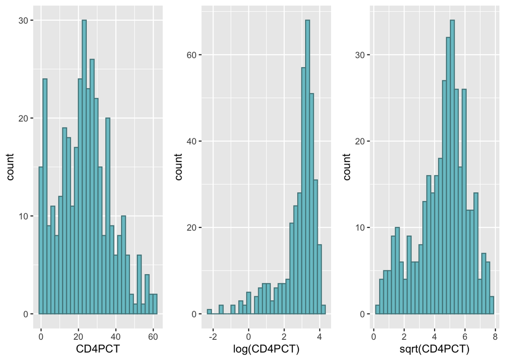

```r
p1 = ggplot(hiv.data, aes(x=CD4PCT))+
  geom_histogram(color="cadetblue4", fill="cadetblue3")

p2 = ggplot(hiv.data, aes(x=log(CD4PCT)))+
  geom_histogram(color="cadetblue4", fill="cadetblue3")

p3 = ggplot(hiv.data, aes(x=sqrt(CD4PCT)))+
  geom_histogram(color="cadetblue4", fill="cadetblue3")

grid.arrange(p1,p2,p3, ncol=3)
```

```r
## Redefining variables
y <- sqrt (CD4PCT)             # we are using the square root of the percentage
age.baseline <- baseage        # kid's age (yrs) at the beginning of the study
age.measurement <- visage      # kids age (yrs) at the time of measurement
treatment <- treatmnt
time <- visage - baseage

length(unique (hiv.data$newpid))   # there are 83 patients in the dataset of length 369
```

```
## [1] 83
```

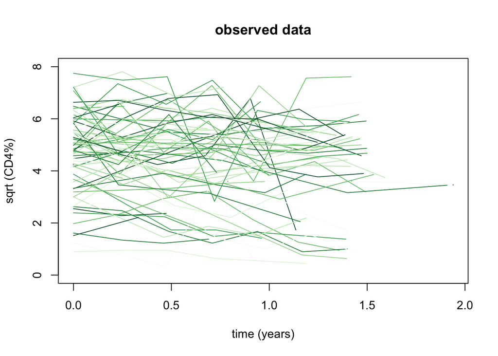

```r
## Set up new patient id numbers from 1 to J
unique.pid <- unique (newpid)
n <- length (y)
J <- length (unique.pid)
person <- rep (NA, n)
for (j in 1:J){
person[newpid==unique.pid[j]] <- j
}

cols <- rep(brewer.pal(8,'Greens'),20)
for (j in 1:J){
if(j==1){
plot(time[newpid==unique.pid[j]], y[newpid==unique.pid[j]], xlab="time (years)", ylab="sqrt (CD4%)",
     main="observed data", cex = .1, ylim=c(0,8))
}
points(time[newpid==unique.pid[j]], y[newpid==unique.pid[j]], col = cols[j], type="l", ylim=c(0,8))
}
```

```r
M1 <- lmer (y ~ time + (1 + time | person))
display (M1)
```

```
## lmer(formula = y ~ time + (1 + time | person))
##             coef.est coef.se
## (Intercept)  4.85     0.16
## time        -0.47     0.13
##
## Error terms:
##  Groups   Name        Std.Dev. Corr
##  person   (Intercept) 1.33
##           time        0.68     0.15
##  Residual             0.75
## ---
## number of obs: 369, groups: person, 83
## AIC = 1108.1, DIC = 1087.8
## deviance = 1091.9
```

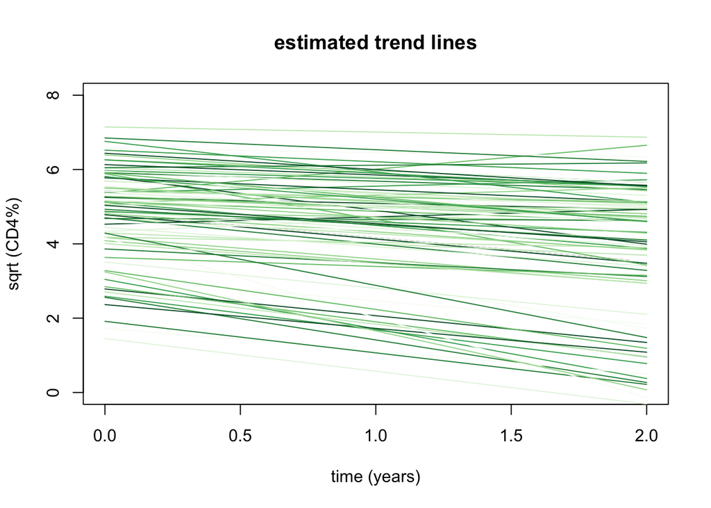

```r
coef.1 <- matrix(0, J, 1)
coef.2 <- matrix(0, J, 1)
coef.1 <- coef(M1)$person[1]
coef.2 <- coef(M1)$person[2]
t = time[newpid==unique.pid[1]]
for (j in 1:J){
    if(j==1){
    plot(t , y=coef.1[j,1] + coef.2[j,1]*t, type="l", xlab="time (years)", ylab="sqrt (CD4%)",
              main="estimated trend lines", xlim=c(0,2), ylim=c(0,8))
    }
  curve(coef.1[j,1] + coef.2[j,1]*x,col=cols[j], add=T)
}
```

```r
CD4.fake <- function(J, K){
  time <- rep (seq(0,1,length=K), J)  # K measurements during the year
  person <- rep (1:J, each=K)         # person ID's
  treatment <- sample (rep(0:1, J/2))
  treatment1 <- treatment[person]
#                                     # hyperparameters
  mu.a.true <- 4.8                    # more generally, these could
  g.0.true <- -.5                     # be specified as additional
  g.1.true <- .5                      # arguments to the function
  sigma.y.true <- .7
  sigma.a.true <- 1.3
  sigma.b.true <- .7
#                                     # personal-level parameters
  a.true <- rnorm (J, mu.a.true, sigma.a.true)
  b.true <- rnorm (J, g.0.true + g.1.true*treatment, sigma.b.true)
#                                     # data
  y <- rnorm (J*K, a.true[person] + b.true[person]*time, sigma.y.true)
  return (data.frame (y, time, person, treatment1))
}

fake.83.7 = CD4.fake (83,7)
head(fake.83.7)
```

```
##          y      time person treatment1
## 1 6.211052 0.0000000      1          1
## 2 4.664025 0.1666667      1          1
## 3 4.623705 0.3333333      1          1
## 4 4.761053 0.5000000      1          1
## 5 4.527662 0.6666667      1          1
## 6 3.566652 0.8333333      1          1
```

```r
dim(fake.83.7)   # 581 x 4    83*7 = 581
```

```
## [1] 581   4
```

```r
unique.pidf <- unique (fake.83.7$person)
nf <- length (y)
Jf <- length (unique.pidf)
personf <- rep (NA, n)
for (j in 1:Jf){
  personf[fake.83.7$person==unique.pidf[j]] <- j
}

## Fit the model
M1f <- lmer (y ~ time + (1 + time | person), data=fake.83.7)
display (M1f)
```

```
## lmer(formula = y ~ time + (1 + time | person), data = fake.83.7)
##             coef.est coef.se
## (Intercept)  4.89     0.13
## time        -0.35     0.13
##
## Error terms:
##  Groups   Name        Std.Dev. Corr
##  person   (Intercept) 1.08
##           time        0.82     0.27
##  Residual             0.70
## ---
## number of obs: 581, groups: person, 83
## AIC = 1563.5, DIC = 1542.4
## deviance = 1547.0
```

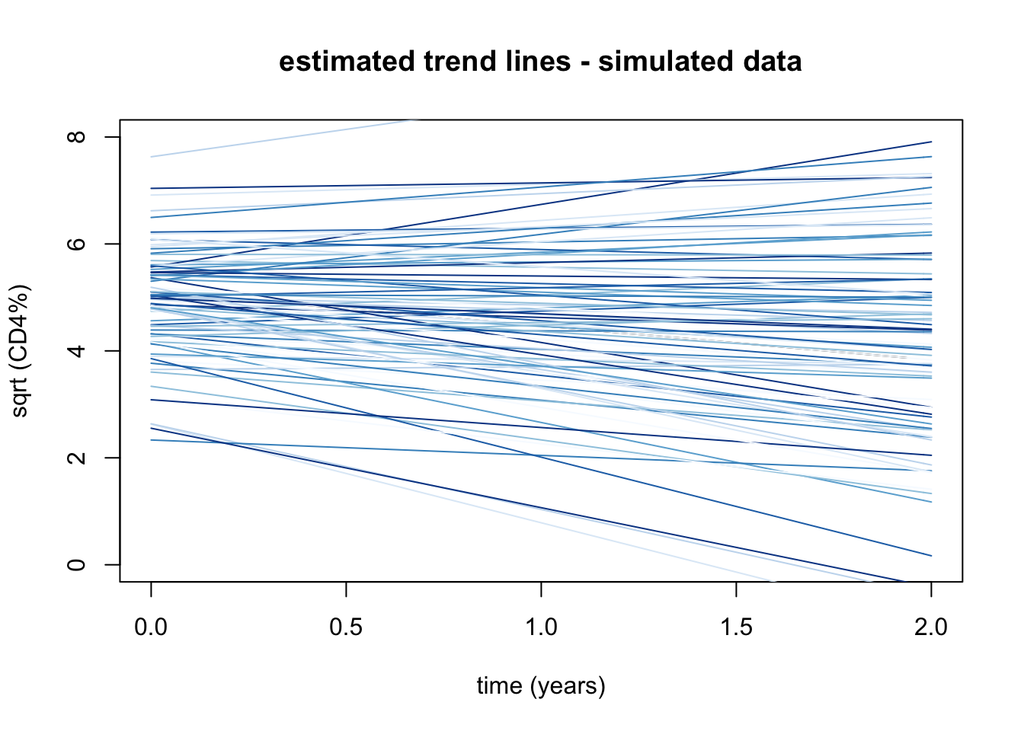

```r
## Figure 20.5 (c) (using fake data)
cols <- rep(brewer.pal(8,'Blues'),20)
coef.1 <- matrix(0, J, 1)
coef.2 <- matrix(0, J, 1)
coef.1 <- coef(M1f)$person[1]
coef.2 <- coef(M1f)$person[2]
t = time[fake.83.7$person==unique.pidf[1]]
for (j in 1:J){
  if(j==1){
    plot(t , y=coef.1[j,1] + coef.2[j,1]*t, type="l", xlab="time (years)", ylab="sqrt (CD4%)",
         main="estimated trend lines - simulated data", xlim=c(0,2), ylim=c(0,8))
  }
  curve(coef.1[j,1] + coef.2[j,1]*x, col = cols[j], add=T)
}
```

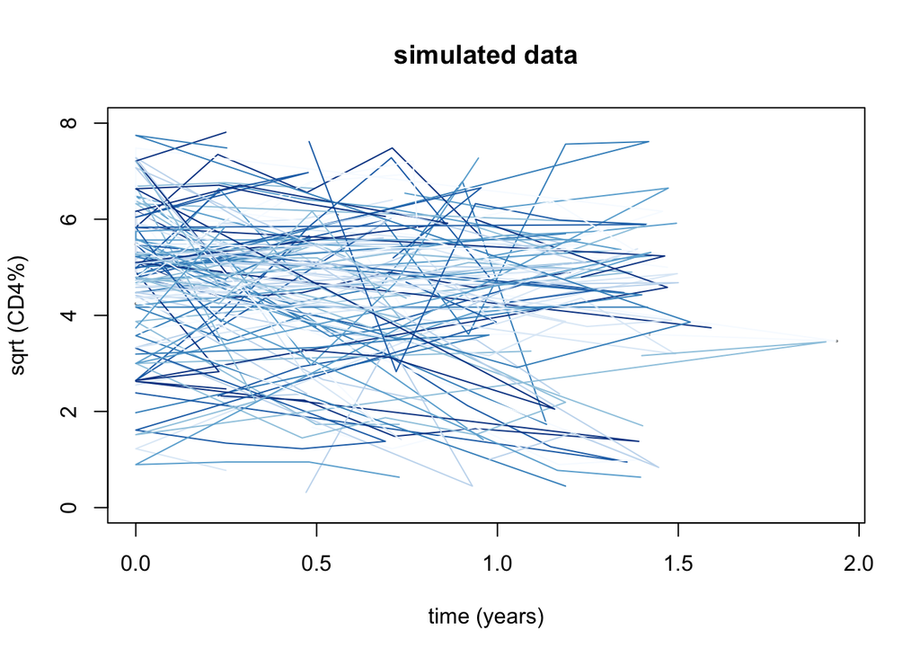

```r
for (j in 1:J){
  if(j==1){
    plot(time[fake.83.7$person==unique.pidf[j]], y[fake.83.7$person==unique.pidf[j]], xlab="time (years)", ylab="sqrt (CD4%)",
         main="simulated data", cex = .1, ylim=c(0,8))
  }
  points(time[fake.83.7$person==unique.pidf[j]], y[fake.83.7$person==unique.pidf[j]], type="l", col=cols[j], ylim=c(0,8))
}
```

```r
CD4.power <- function (J, K, n.sims=1000){
  signif <- rep (NA, n.sims)
  for (s in 1:n.sims){
    fake <- CD4.fake (J,K)
    lme.power <- lmer (y ~ time + time:treatment1 + (1 + time | person),
         data=fake)
    theta.hat <- fixef(lme.power)["time:treatment1"]
    theta.se <- se.fixef(lme.power)["time:treatment1"]
    signif[s] <- (theta.hat - 2*theta.se) > 0    # return TRUE or FALSE
  }
  power <- mean (signif)                         # proportion of TRUE
  return (power)
}

##  these really vary wildly from run to run if nsims is only 100
CD4.power (J=150, K=7, n.sims=100)
```

```
## [1] 0.84
```

```r
CD4.power (J=110, K=7, n.sims=100)
```

```
## [1] 0.75
```

```r
CD4.power (J=80, K=7, n.sims=100)
```

```
## [1] 0.57
```

```r
CD4.power (J=50, K=7, n.sims=100)
```

```
## boundary (singular) fit: see help('isSingular')
```

```
## boundary (singular) fit: see help('isSingular')
```

```
## [1] 0.52
```

```r
J.values <- c(15, 60, 100, 150, 200, 225, 250, 300, 400)
n.sims.values <- rep(1000,9)
K.values <- c(3,5,7,10)
#power.values <- array (NA, c(length(J.values),length(K.values)))
#  for (i1 in 1:length(J.values)){
#  for (i2 in 1:length(K.values)){
#    #cat ("computing power calculation for J =", J.values[i1], ", K =", K.values[i2], "\n")
#    power.values[i1,i2] <- CD4.power (J=J.values[i1], K=K.values[i2], n.sims=n.sims.values[i1])
#    #cat ("power =", power.values[i1,i2], "\n")
#  }
#}

#save(power.values, J.values, n.sims.values, K.values, file = 'powervalues3.RData')
load('powervalues3.RData')

dfp = as.data.frame(cbind(seq(1:length(J.values)), J.values, power.values))
colnames(dfp) = c("ID", "J.values", "K=3", "K=5","K=7", "K=10")
dfpmelt = melt(dfp,id = c("ID", "J.values"))
```

### (b)

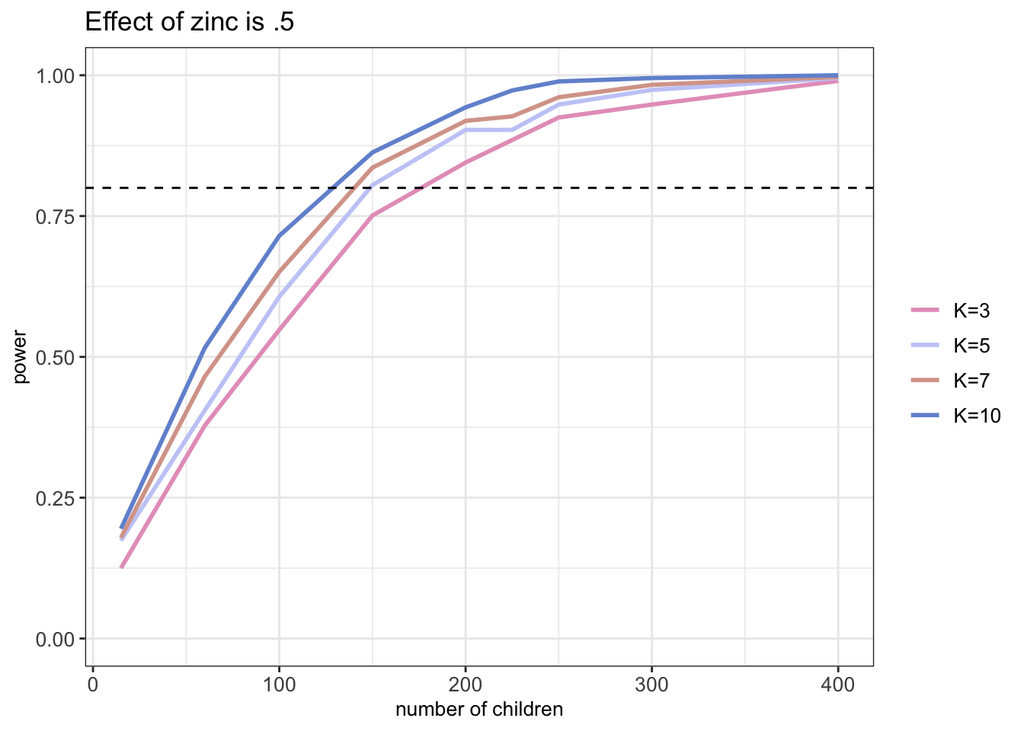

```r
p <- ggplot(dfpmelt, aes(x = J.values, y = value, color = variable)) +
  geom_line(size=1) + ylim(0, 1) +
  scale_color_manual(values = wes_palette("GrandBudapest2", n = 4)) +
  theme_bw() +
  theme(axis.text=element_text(size=10),
        axis.title=element_text(size=10),
        legend.text=element_text(size=10)) +
  geom_hline(yintercept = 0.80, linetype = 2) +
  xlab("number of children") + ylab("power") +
  ggtitle("Effect of zinc is .5") +
  theme(legend.title = element_blank())
p
```

# Problem 3

```r
load("/Users/Home/Documents/Michael_Ghattas/School/CU_Boulder/BA-BS/2022/Spring 2022/STAT - 4400/Data/schooldata.Rdata")
head(schooldata)
```

```
##   id    extro     open    agree    social class school
## 1  1 63.69356 43.43306 38.02668  75.05811     d     IV
## 2  2 69.48244 46.86979 31.48957  98.12560     a     VI
## 3  3 79.74006 32.27013 40.20866 116.33897     d     VI
## 4  4 62.96674 44.40790 30.50866  90.46888     c     IV
## 5  5 64.24582 36.86337 37.43949  98.51873     d     IV
## 6  6 50.97107 46.25627 38.83196  75.21992     d      I
```

### (a)

```r
mod1 <- lm(extro ~ open + agree + social, data = schooldata)
summary(mod1)
```

```
##
## Call:
## lm(formula = extro ~ open + agree + social, data = schooldata)
##
## Residuals:
##      Min       1Q   Median       3Q      Max
## -30.3151  -6.0743  -0.1586   6.2851  30.0167
##
## Coefficients:
##              Estimate Std. Error t value Pr(>|t|)
## (Intercept) 57.839518   3.148056  18.373   <2e-16 ***
## open         0.024749   0.046471   0.533    0.594
## agree        0.026538   0.053347   0.497    0.619
## social       0.005082   0.017303   0.294    0.769
## ---
## Signif. codes:  0 '***' 0.001 '**' 0.01 '*' 0.05 '.' 0.1 ' ' 1
##
## Residual standard error: 9.342 on 1196 degrees of freedom
## Multiple R-squared:  0.0005222,  Adjusted R-squared:  -0.001985
## F-statistic: 0.2083 on 3 and 1196 DF,  p-value: 0.8907
```

```r
display(mod1)
```

```
## lm(formula = extro ~ open + agree + social, data = schooldata)
##             coef.est coef.se
## (Intercept) 57.84     3.15
## open         0.02     0.05
## agree        0.03     0.05
## social       0.01     0.02
## ---
## n = 1200, k = 4
## residual sd = 9.34, R-Squared = 0.00
```

The model is unhelpful, we are unable to make any inference with certinty, and the response looks independent from the predictors for the most part.

### (b)

```r
require(lme4)

mod2 <- lmer (extro ~ open + agree + social + (open | school) + (agree | school) + (social | school), data = schooldata)
```

```
## boundary (singular) fit: see help('isSingular')
```

```r
summary(mod2)
```

```
## Linear mixed model fit by REML ['lmerMod']
## Formula: extro ~ open + agree + social + (open | school) + (agree | school) +
##     (social | school)
##    Data: schooldata
##
## REML criterion at convergence: 5821
##
## Scaled residuals:
##     Min      1Q  Median      3Q     Max
## -5.8769 -0.5140  0.0006  0.5174  6.0296
##
## Random effects:
##  Groups   Name        Variance  Std.Dev. Corr
##  school   (Intercept) 2.469e+01 4.96860
##           open        2.504e-04 0.01582  1.00
##  school.1 (Intercept) 2.474e+01 4.97437
##           agree       1.414e-05 0.00376  -1.00
##  school.2 (Intercept) 2.455e+01 4.95520
##           social      1.123e-04 0.01059  1.00
##  Residual             7.102e+00 2.66487
## Number of obs: 1200, groups:  school, 6
##
## Fixed effects:
##              Estimate Std. Error t value
## (Intercept) 59.121156   3.625935  16.305
## open         0.009540   0.014814   0.644
## agree        0.027026   0.015359   1.760
## social      -0.001843   0.006576  -0.280
##
## Correlation of Fixed Effects:
##        (Intr) open   agree
## open    0.112
## agree  -0.201 -0.008
## social  0.265  0.002 -0.003
## optimizer (nloptwrap) convergence code: 0 (OK)
## boundary (singular) fit: see help('isSingular')
```

```r
display(mod2)
```

```
## lmer(formula = extro ~ open + agree + social + (open | school) +
##     (agree | school) + (social | school), data = schooldata)
##             coef.est coef.se
## (Intercept) 59.12     3.63
## open         0.01     0.01
## agree        0.03     0.02
## social       0.00     0.01
##
## Error terms:
##  Groups   Name        Std.Dev. Corr
##  school   (Intercept) 4.97
##           open        0.02     1.00
##  school.1 (Intercept) 4.97
##           agree       0.00     -1.00
##  school.2 (Intercept) 4.96
##           social      0.01     1.00
##  Residual             2.66
```

```
## ---
## number of obs: 1200, groups: school, 6
## AIC = 5849, DIC = 5785.7
## deviance = 5803.4
```

With this model, the parameters are estimated as follows:

Unexplained within-school variation $\widehat{\sigma}_y$ = 2.66 \

School-Open intercepts variation $\widehat{\sigma}_{\alpha}$ = 4.97 \ School-agree intercepts variation $\widehat{\sigma}_{\alpha}$ = 4.97 \ School-Social intercepts variation $\widehat{\sigma}_{\alpha}$ = 4.96 \

School-Open slopes variation $\widehat{\sigma}_{\beta}$ = 0.02 \ School-agree slopes variation $\widehat{\sigma}_{\beta}$ = 0.00 \ School-Social slopes variation $\widehat{\sigma}_{\beta}$ = 0.01 \

Correlation between intercepts and slopes (School-Open) $ $ = 1 \ Correlation between intercepts and slopes (School-agree) $ $ = -1 \ Correlation between intercepts and slopes (School-Social) $ $ = 1 \

### (c)

```r
require(lme4)

mod3 <- lmer (extro ~ open + agree + social + school:class + (1 + open | school) + (1 + open | school:class) + (1 + agree | school:class) + (1 + social | school:class), data = schooldata)
```

```
## fixed-effect model matrix is rank deficient so dropping 1 column / coefficient
```

```
## boundary (singular) fit: see help('isSingular')
```

```r
summary(mod3)
```

```
## Linear mixed model fit by REML ['lmerMod']
## Formula: extro ~ open + agree + social + school:class + (1 + open | school) +
##     (1 + open | school:class) + (1 + agree | school:class) +
##     (1 + social | school:class)
##    Data: schooldata
##
## REML criterion at convergence: 3418.4
##
## Scaled residuals:
##     Min      1Q  Median      3Q     Max
## -9.9923 -0.3343  0.0042  0.3386 10.6753
##
## Random effects:
##  Groups         Name        Variance  Std.Dev.  Corr
##  school.class   (Intercept) 9.690e-01 0.9843771
##                 social      2.401e-11 0.0000049 -1.00
##  school.class.1 (Intercept) 9.652e-01 0.9824428
##                 agree       4.023e-05 0.0063426 -0.95
##  school.class.2 (Intercept) 9.693e-01 0.9845173
##                 open        7.326e-06 0.0027066 -1.00
##  school         (Intercept) 9.638e-01 0.9817460
##                 open        5.878e-06 0.0024245 0.13
##  Residual                   9.670e-01 0.9833553
## Number of obs: 1200, groups:  school:class, 24; school, 6
##
## Fixed effects:
##                    Estimate Std. Error t value
## (Intercept)       7.999e+01  1.854e+00  43.137
## open              6.150e-03  5.093e-03   1.208
## agree            -7.650e-03  5.848e-03  -1.308
## social            5.361e-04  1.852e-03   0.289
## schoolI:classa   -3.973e+01  2.574e+00 -15.434
## schoolII:classa  -2.775e+01  2.569e+00 -10.799
## schoolIII:classa -2.309e+01  2.573e+00  -8.972
## schoolIV:classa  -1.946e+01  2.575e+00  -7.558
## schoolV:classa   -1.517e+01  2.572e+00  -5.900
## schoolVI:classa  -1.015e+01  2.151e+00  -4.719
## schoolI:classb   -3.432e+01  2.573e+00 -13.339
## schoolII:classb  -2.639e+01  2.571e+00 -10.265
## schoolIII:classb -2.224e+01  2.572e+00  -8.646
## schoolIV:classb  -1.829e+01  2.570e+00  -7.115
## schoolV:classb   -1.390e+01  2.574e+00  -5.401
## schoolVI:classb  -8.153e+00  2.144e+00  -3.803
## schoolI:classc   -3.161e+01  2.572e+00 -12.289
## schoolII:classc  -2.523e+01  2.572e+00  -9.807
## schoolIII:classc -2.124e+01  2.575e+00  -8.246
## schoolIV:classc  -1.726e+01  2.571e+00  -6.713
## schoolV:classc   -1.287e+01  2.573e+00  -5.003
## schoolVI:classc  -5.309e+00  2.146e+00  -2.473
## schoolI:classd   -2.974e+01  2.574e+00 -11.554
## schoolII:classd  -2.423e+01  2.570e+00  -9.429
## schoolIII:classd -2.011e+01  2.571e+00  -7.825
## schoolIV:classd  -1.623e+01  2.572e+00  -6.312
## schoolV:classd   -1.161e+01  2.570e+00  -4.518
```

```
##
## Correlation matrix not shown by default, as p = 27 > 12.
## Use print(x, correlation=TRUE)  or
##     vcov(x)        if you need it
```

```
## fit warnings:
## fixed-effect model matrix is rank deficient so dropping 1 column / coefficient
## optimizer (nloptwrap) convergence code: 0 (OK)
## boundary (singular) fit: see help('isSingular')
```

```r
display(mod3)
```

```
## lmer(formula = extro ~ open + agree + social + school:class +
##     (1 + open | school) + (1 + open | school:class) + (1 + agree |
##     school:class) + (1 + social | school:class), data = schooldata)
##                  coef.est coef.se
## (Intercept)       79.99     1.85
## open               0.01     0.01
## agree             -0.01     0.01
## social             0.00     0.00
## schoolI:classa   -39.73     2.57
## schoolII:classa  -27.75     2.57
## schoolIII:classa -23.09     2.57
## schoolIV:classa  -19.46     2.58
## schoolV:classa   -15.17     2.57
## schoolVI:classa  -10.15     2.15
## schoolI:classb   -34.32     2.57
## schoolII:classb  -26.39     2.57
## schoolIII:classb -22.24     2.57
## schoolIV:classb  -18.29     2.57
## schoolV:classb   -13.90     2.57
## schoolVI:classb   -8.15     2.14
## schoolI:classc   -31.61     2.57
## schoolII:classc  -25.23     2.57
## schoolIII:classc -21.24     2.58
## schoolIV:classc  -17.26     2.57
## schoolV:classc   -12.87     2.57
## schoolVI:classc   -5.31     2.15
## schoolI:classd   -29.74     2.57
## schoolII:classd  -24.23     2.57
## schoolIII:classd -20.11     2.57
## schoolIV:classd  -16.23     2.57
## schoolV:classd   -11.61     2.57
##
## Error terms:
##  Groups         Name        Std.Dev. Corr
##  school.class   (Intercept) 0.98
##                 social      0.00     -1.00
##  school.class.1 (Intercept) 0.98
##                 agree       0.01     -0.95
##  school.class.2 (Intercept) 0.98
##                 open        0.00     -1.00
##  school         (Intercept) 0.98
##                 open        0.00     0.13
##  Residual                   0.98
```

```
## ---
## number of obs: 1200, groups: school:class, 24; school, 6
## AIC = 3498.4, DIC = 3281
## deviance = 3349.7
```

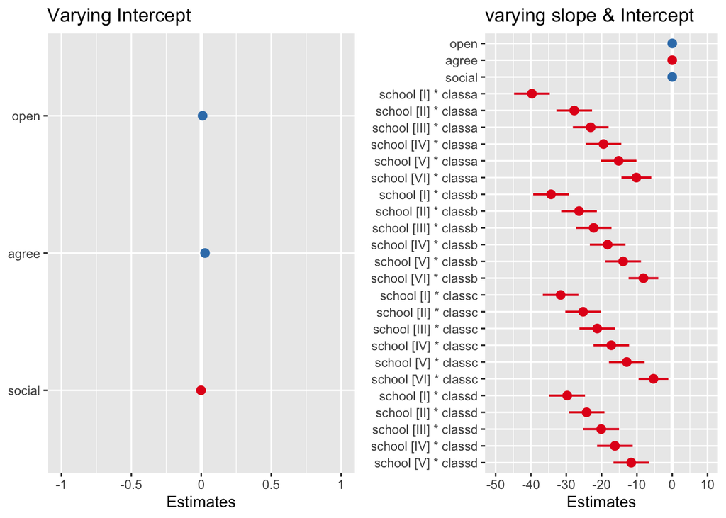

```r
library(sjPlot) #for plotting lmer and glmer mods
library(gridExtra)

plot1 = plot_model(mod2, show.values=FALSE, show.p=TRUE, title="Varying Intercept")
plot2 = plot_model(mod3, show.values=FALSE, show.p=TRUE, title="varying slope & Intercept")

grid.arrange(plot1, plot2, ncol = 2)
```